# cHoltLaury

Nathaniel Phillips

20 March 2017

# Questions

- How could competitive affect choices in the Holt and Laury (2002) gambles?

# Conclusions

## Holt and Laury Gambles

Here are the 10 gambles from Holt & Laury (2002)

| index | a.x | a.px | a.y | a.py | b.x | b.px | b.y | b.py | a.ev | b.ev | a.var | b.var | ev.diff | high.ev.option |
| --- | --- | --- | --- | --- | --- | --- | --- | --- | --- | --- | --- | --- | --- | --- |
| 1 | 2 | 0.1 | 1.6 | 0.9 | 3.85 | 0.1 | 0.1 | 0.9 | 1.64 | 0.48 | 0.01 | 1.27 | 1.17 | a |
| 2 | 2 | 0.2 | 1.6 | 0.8 | 3.85 | 0.2 | 0.1 | 0.8 | 1.68 | 0.85 | 0.03 | 2.25 | 0.83 | a |
| 3 | 2 | 0.3 | 1.6 | 0.7 | 3.85 | 0.3 | 0.1 | 0.7 | 1.72 | 1.23 | 0.03 | 2.95 | 0.49 | a |
| 4 | 2 | 0.4 | 1.6 | 0.6 | 3.85 | 0.4 | 0.1 | 0.6 | 1.76 | 1.60 | 0.04 | 3.38 | 0.16 | a |
| 5 | 2 | 0.5 | 1.6 | 0.5 | 3.85 | 0.5 | 0.1 | 0.5 | 1.80 | 1.98 | 0.04 | 3.52 | -0.18 | b |
| 6 | 2 | 0.6 | 1.6 | 0.4 | 3.85 | 0.6 | 0.1 | 0.4 | 1.84 | 2.35 | 0.04 | 3.38 | -0.51 | b |
| 7 | 2 | 0.7 | 1.6 | 0.3 | 3.85 | 0.7 | 0.1 | 0.3 | 1.88 | 2.73 | 0.03 | 2.95 | -0.84 | b |
| 8 | 2 | 0.8 | 1.6 | 0.2 | 3.85 | 0.8 | 0.1 | 0.2 | 1.92 | 3.10 | 0.03 | 2.25 | -1.18 | b |
| 9 | 2 | 0.9 | 1.6 | 0.1 | 3.85 | 0.9 | 0.1 | 0.1 | 1.96 | 3.48 | 0.01 | 1.27 | -1.52 | b |
| 10 | 2 | 1.0 | 1.6 | 0.0 | 3.85 | 1.0 | 0.1 | 0.0 | 2.00 | 3.85 | 0.00 | 0.00 | -1.85 | b |

Here are the gambles represented in a coordinate space:

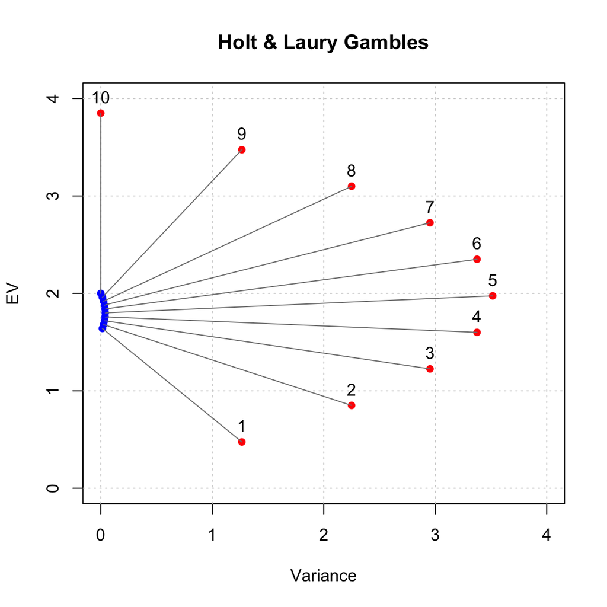

### Introducing competition

For each gamble pair, I calculated the probability that gamble A would beat gamble B given a one shot game. For example, for pair 4, the probability that gamble A (the safe gamble) wins is $.40 \times 0.6 + 0.60 \times 0.60 = 0.60$. Here are the results

| index | ev.diff | high.ev.option | p.a.wins |
| --- | --- | --- | --- |
| 1 | 1.17 | a | 0.9 |
| 2 | 0.83 | a | 0.8 |
| 3 | 0.49 | a | 0.7 |
| 4 | 0.16 | a | 0.6 |
| 5 | -0.18 | b | 0.5 |
| 6 | -0.51 | b | 0.4 |
| 7 | -0.84 | b | 0.3 |
| 8 | -1.18 | b | 0.2 |
| 9 | -1.52 | b | 0.1 |
| 10 | -1.85 | b | 0.0 |

### Introducing risk aversion and risk seeking

To introduce risk aversion and risk seeking, we transform the outcomes by $\frac{x^{1-r}}{1-r}$ according to (Holt, Laury, and others 2002). r < - indicates risk seeking, r = 0 indicates risk neutrality, and r > 0 indicates risk aversion.

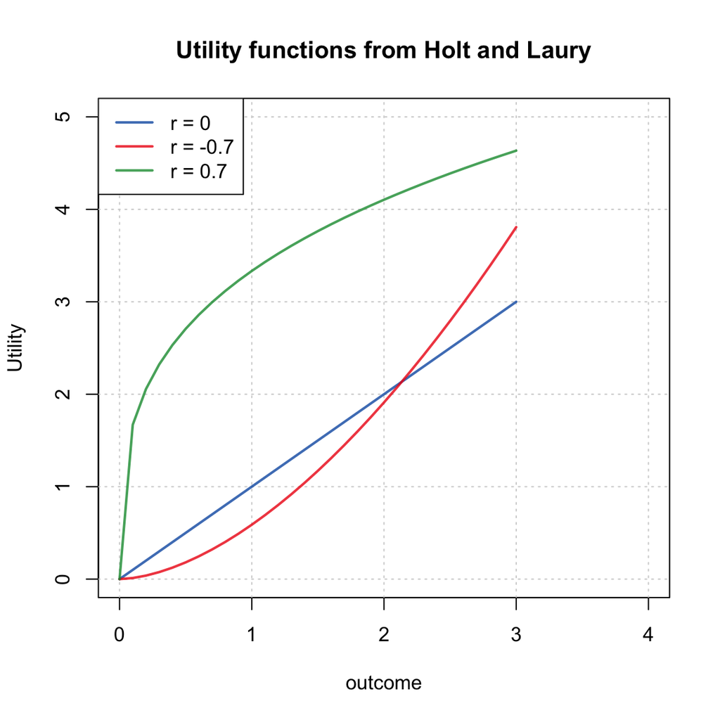

Utility functions

About 70% of the subjects from (Holt, Laury, and others 2002) were risk averse. Here are results for someone with high risk aversion of r = .7. This person switches to the risky gamble at option 8:

Option expected utilities and decisions for risk averse subjects with r = .7

| index | a.eu | b.eu | eu.diff | high.eu.option |
| --- | --- | --- | --- | --- |
| 1 | 3.86 | 2.00 | 1.86 | a |
| 2 | 3.89 | 2.34 | 1.56 | a |
| 3 | 3.92 | 2.67 | 1.25 | a |
| 4 | 3.94 | 3.00 | 0.94 | a |
| 5 | 3.97 | 3.33 | 0.64 | a |
| 6 | 4.00 | 3.67 | 0.33 | a |
| 7 | 4.02 | 4.00 | 0.03 | a |
| 8 | 4.05 | 4.33 | -0.28 | b |
| 9 | 4.08 | 4.66 | -0.59 | b |
| 10 | 4.10 | 4.99 | -0.89 | b |

### Adding bonuses

Now we can add different bonus magnitudes and see how it affects choices:

### Risk averse: r = .7, bonus = 0

Risk averse participant with no bonus

EU calculations with r = 0.7 and reward bonus of 0

| index | a.eu | b.eu | a.eu.pb | b.eu.pb | eu.pb.diff | high.eu.option | high.eu.pb.option |
| --- | --- | --- | --- | --- | --- | --- | --- |
| 1 | 3.86 | 2.00 | 3.86 | 2.00 | 1.86 | a | a |
| 2 | 3.89 | 2.34 | 3.89 | 2.34 | 1.56 | a | a |
| 3 | 3.92 | 2.67 | 3.92 | 2.67 | 1.25 | a | a |
| 4 | 3.94 | 3.00 | 3.94 | 3.00 | 0.94 | a | a |
| 5 | 3.97 | 3.33 | 3.97 | 3.33 | 0.64 | a | a |
| 6 | 4.00 | 3.67 | 4.00 | 3.67 | 0.33 | a | a |
| 7 | 4.02 | 4.00 | 4.02 | 4.00 | 0.03 | a | a |
| 8 | 4.05 | 4.33 | 4.05 | 4.33 | -0.28 | b | b |
| 9 | 4.08 | 4.66 | 4.08 | 4.66 | -0.59 | b | b |
| 10 | 4.10 | 4.99 | 4.10 | 4.99 | -0.89 | b | b |

### Risk averse: r = .7, bonus = 1

Risk averse participant with a moderate reward bonus of 1.

EU calculations with r = 0.7 and reward bonus of 1

| index | a.eu | b.eu | a.eu.pb | b.eu.pb | eu.pb.diff | high.eu.option | high.eu.pb.option |
| --- | --- | --- | --- | --- | --- | --- | --- |
| 1 | 3.86 | 2.00 | 6.86 | 2.34 | 4.53 | a | a |
| 2 | 3.89 | 2.34 | 6.56 | 3.00 | 3.56 | a | a |
| 3 | 3.92 | 2.67 | 6.25 | 3.67 | 2.58 | a | a |
| 4 | 3.94 | 3.00 | 5.94 | 4.33 | 1.61 | a | a |
| 5 | 3.97 | 3.33 | 5.64 | 5.00 | 0.64 | a | a |
| 6 | 4.00 | 3.67 | 5.33 | 5.67 | -0.33 | a | b |
| 7 | 4.02 | 4.00 | 5.02 | 6.33 | -1.31 | a | b |
| 8 | 4.05 | 4.33 | 4.72 | 7.00 | -2.28 | b | b |
| 9 | 4.08 | 4.66 | 4.41 | 7.66 | -3.25 | b | b |
| 10 | 4.10 | 4.99 | 4.10 | 8.33 | -4.22 | b | b |

### Risk seeking: r = -.7, bonus = 0

Risk seeking participant with no bonus

EU calculations with r = -0.7 and reward bonus of 0

| index | a.eu | b.eu | a.eu.pb | b.eu.pb | eu.pb.diff | high.eu.option | high.eu.pb.option |
| --- | --- | --- | --- | --- | --- | --- | --- |
| 1 | 1.37 | 0.59 | 1.37 | 0.59 | 0.78 | a | a |
| 2 | 1.43 | 1.17 | 1.43 | 1.17 | 0.26 | a | a |
| 3 | 1.49 | 1.75 | 1.49 | 1.75 | -0.27 | b | b |
| 4 | 1.55 | 2.33 | 1.55 | 2.33 | -0.79 | b | b |
| 5 | 1.61 | 2.92 | 1.61 | 2.92 | -1.31 | b | b |
| 6 | 1.67 | 3.50 | 1.67 | 3.50 | -1.83 | b | b |
| 7 | 1.73 | 4.08 | 1.73 | 4.08 | -2.35 | b | b |
| 8 | 1.79 | 4.66 | 1.79 | 4.66 | -2.87 | b | b |
| 9 | 1.85 | 5.24 | 1.85 | 5.24 | -3.39 | b | b |
| 10 | 1.91 | 5.82 | 1.91 | 5.82 | -3.91 | b | b |

### Risk seeking: r = -.7, bonus = 1

Risk seeking participant with a moderate reward bonus of 1

EU calculations with r = -0.7 and reward bonus of 1

| index | a.eu | b.eu | a.eu.pb | b.eu.pb | eu.pb.diff | high.eu.option | high.eu.pb.option |
| --- | --- | --- | --- | --- | --- | --- | --- |
| 1 | 1.37 | 0.59 | 1.90 | 0.65 | 1.25 | a | a |
| 2 | 1.43 | 1.17 | 1.90 | 1.29 | 0.61 | a | a |
| 3 | 1.49 | 1.75 | 1.90 | 1.93 | -0.03 | b | b |
| 4 | 1.55 | 2.33 | 1.90 | 2.57 | -0.67 | b | b |
| 5 | 1.61 | 2.92 | 1.90 | 3.21 | -1.31 | b | b |
| 6 | 1.67 | 3.50 | 1.91 | 3.85 | -1.94 | b | b |
| 7 | 1.73 | 4.08 | 1.91 | 4.49 | -2.58 | b | b |
| 8 | 1.79 | 4.66 | 1.91 | 5.13 | -3.22 | b | b |
| 9 | 1.85 | 5.24 | 1.91 | 5.77 | -3.86 | b | b |
| 10 | 1.91 | 5.82 | 1.91 | 6.41 | -4.50 | b | b |

### Risk seeking: r = -.7, bonus = 5

Risk seeking participant with a large reward bonus of 5.

EU calculations with r = -0.7 and reward bonus of 5

| index | a.eu | b.eu | a.eu.pb | b.eu.pb | eu.pb.diff | high.eu.option | high.eu.pb.option |
| --- | --- | --- | --- | --- | --- | --- | --- |
| 1 | 1.37 | 0.59 | 9.53 | 1.50 | 8.03 | a | a |
| 2 | 1.43 | 1.17 | 8.69 | 2.99 | 5.70 | a | a |
| 3 | 1.49 | 1.75 | 7.84 | 4.48 | 3.36 | b | a |
| 4 | 1.55 | 2.33 | 6.99 | 5.96 | 1.03 | b | a |
| 5 | 1.61 | 2.92 | 6.15 | 7.45 | -1.31 | b | b |
| 6 | 1.67 | 3.50 | 5.30 | 8.94 | -3.64 | b | b |
| 7 | 1.73 | 4.08 | 4.45 | 10.43 | -5.98 | b | b |
| 8 | 1.79 | 4.66 | 3.61 | 11.92 | -8.31 | b | b |
| 9 | 1.85 | 5.24 | 2.76 | 13.40 | -10.65 | b | b |
| 10 | 1.91 | 5.82 | 1.91 | 14.89 | -12.98 | b | b |

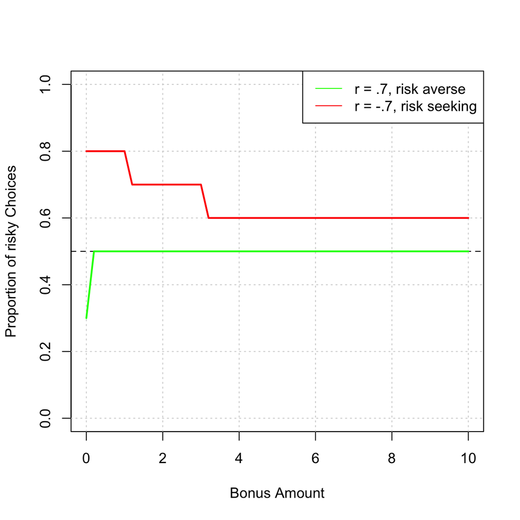

Proportion of risky choices given magnitude of a competitive bonus

## HL Game theoretic

- For each gamble pair, calculate a 2 x 2 table calculating the probability of winning. Look for game theoretic equilibriums

For example, here is a 2 x 2 competition table for gamble pair 3:

|  | Y.A | Y.B |
| --- | --- | --- |
| X.A | 0.5 | 0.7 |
| X.B | 0.3 | 0.5 |

- For gamble pair 3, there is an equilibrium where both players choose option A (the safe option, high EV option).

Here is the the table for gamble pair 7:

|  | Y.A | Y.B |
| --- | --- | --- |
| X.A | 0.5 | 0.3 |
| X.B | 0.7 | 0.5 |

- For game pair 7, there is an equilibrum where both players choose option B (the risky, high EV option)

### Conclusion

- Assuming both players are risk neutral, there is an equilibrium for each gamble pair where both players should choose the high EV option

## References

Holt, Charles A, Susan K Laury, and others. 2002. “Risk Aversion and Incentive Effects.” *American Economic Review* 92 (5). American Economic Association: 1644–55.